# Project 3: What Characteristics Are Associated with Poor Hospital Performance?

Merrimack College DSE6630: Healthcare & Life Sciences Analytics

Peter Gyorda

26 June 2026

# 1 Background to the Project

## 1.1 Overview

Hospital quality has become an increasingly important focus for healthcare organizations, patients, and policymakers. The Centers for Medicare & Medicaid Services (CMS) publicly reports a variety of quality measures, including mortality, readmission, and patient safety outcomes. These measures provide an opportunity to identify characteristics associated with poor-performing hospitals and to better understand factors that may influence quality of care.

This project analyzes publicly available CMS hospital quality data to determine whether hospital characteristics, such as ownership, hospital type, emergency service availability, and geographic location, are associated with poor performance. The analysis also explores whether these characteristics can be used to predict poor-performing hospitals using machine learning techniques.

## 1.2 Background

CMS reports numerous quality measures for hospitals across the United States. Rather than relying solely on an overall hospital rating, this project creates a custom **Poor Performance Score** by combining the number of mortality, readmission, and patient safety measures in which each hospital performed worse than the national average. This approach provides a more detailed assessment of hospital performance across multiple quality domains.

## 1.3 Project Objectives

The objectives of this project are to:

- Explore the distribution of hospital quality performance across the United States.
- Identify hospital characteristics associated with poor performance.
- Evaluate differences in performance based on hospital ownership, hospital type, and emergency service availability.
- Examine geographic variation in hospital quality.
- Develop a Random Forest model to determine whether publicly available hospital characteristics can predict poor-performing hospitals.
- Provide recommendations that hospital administrators can use to prioritize quality improvement efforts.

## 1.4 Stakeholder

The primary stakeholders for this analysis are hospital administrators and healthcare system leadership teams seeking to identify organizational characteristics associated with poor hospital performance and opportunities for quality improvement.

# 2 Data Import and Initial Exploration

## 2.1 Load the CMS Hospital Dataset

```r
library(readr)

hospital <- read_csv("Hospital_General_Information.csv")
```

## 2.2 Examine the Dataset

```r
dim(hospital)
```

```
## [1] 5394   39
```

```r
names(hospital)
```

```
##  [1] "Facility ID"
##  [2] "Facility Name"
##  [3] "Address"
##  [4] "City/Town"
##  [5] "State"
##  [6] "ZIP Code"
##  [7] "County/Parish"
##  [8] "Telephone Number"
##  [9] "Hospital Type"
## [10] "Hospital Ownership"
## [11] "Emergency Services"
## [12] "Meets criteria for promoting interoperability of EHRs"
## [13] "Meets criteria for birthing friendly designation"
## [14] "Hospital overall rating"
## [15] "Hospital overall rating footnote"
```

[output cut: 24 more lines]

```r
glimpse(hospital)
```

```
## Rows: 5,394
## Columns: 39
## $ `Facility ID`                                           <chr> "010001", "010…
## $ `Facility Name`                                         <chr> "SOUTHEAST HEA…
## $ Address                                                 <chr> "1108 ROSS CLA…
## $ `City/Town`                                             <chr> "DOTHAN", "BOA…
## $ State                                                   <chr> "AL", "AL", "A…
## $ `ZIP Code`                                              <chr> "36301", "3595…
## $ `County/Parish`                                         <chr> "HOUSTON", "MA…
## $ `Telephone Number`                                      <chr> "(334) 793-870…
## $ `Hospital Type`                                         <chr> "Acute Care Ho…
## $ `Hospital Ownership`                                    <chr> "Government - …
## $ `Emergency Services`                                    <chr> "Yes", "Yes", …
## $ `Meets criteria for promoting interoperability of EHRs` <chr> "Y", "Y", "Y",…
## $ `Meets criteria for birthing friendly designation`      <chr> "Y", NA, "Y", …
```

[output cut: 26 more lines]

```r
summary(hospital)
```

```
##  Facility ID        Facility Name        Address           City/Town
##  Length:5394        Length:5394        Length:5394        Length:5394
##  Class :character   Class :character   Class :character   Class :character
##  Mode  :character   Mode  :character   Mode  :character   Mode  :character
##
##
##
##
##     State             ZIP Code         County/Parish      Telephone Number
##  Length:5394        Length:5394        Length:5394        Length:5394
##  Class :character   Class :character   Class :character   Class :character
##  Mode  :character   Mode  :character   Mode  :character   Mode  :character
##
##
##
##
##  Hospital Type      Hospital Ownership Emergency Services
##  Length:5394        Length:5394        Length:5394
##  Class :character   Class :character   Class :character
##  Mode  :character   Mode  :character   Mode  :character
##
##
##
##
##  Meets criteria for promoting interoperability of EHRs
##  Length:5394
##  Class :character
##  Mode  :character
##
##
##
##
##  Meets criteria for birthing friendly designation Hospital overall rating
##  Length:5394                                      Length:5394
##  Class :character                                 Class :character
##  Mode  :character                                 Mode  :character
##
##
##
##
```

[output cut: 81 more lines]

```
##  Length:5394                       Min.   : 5.00         Length:5394
##  Class :character                  1st Qu.: 5.00         Class :character
##  Mode  :character                  Median : 5.00         Mode  :character
##                                    Mean   :10.04
##                                    3rd Qu.:19.00
##                                    Max.   :22.00
##                                    NA's   :3212
##  Count of Facility TE Measures TE Group Footnote
##  Length:5394                   Min.   : 5.00
##  Class :character              1st Qu.:19.00
##  Mode  :character              Median :19.00
##                                Mean   :17.63
##                                3rd Qu.:19.00
##                                Max.   :22.00
##                                NA's   :4523
```

## 2.3 Missing Data Assessment

```r
colSums(is.na(hospital))
```

```
##                                           Facility ID
##                                                     0
##                                         Facility Name
##                                                     0
##                                               Address
##                                                     0
##                                             City/Town
##                                                     0
##                                                 State
##                                                     0
##                                              ZIP Code
##                                                     0
##                                         County/Parish
##                                                     0
##                                      Telephone Number
##                                                     0
##                                         Hospital Type
##                                                     0
##                                    Hospital Ownership
##                                                     0
##                                    Emergency Services
##                                                     0
## Meets criteria for promoting interoperability of EHRs
##                                                  1507
##      Meets criteria for birthing friendly designation
##                                                  3159
##                               Hospital overall rating
##                                                     0
##                      Hospital overall rating footnote
##                                                  2780
##                              MORT Group Measure Count
##                                                     0
##                       Count of Facility MORT Measures
##                                                     0
##                         Count of MORT Measures Better
##                                                     0
##                   Count of MORT Measures No Different
##                                                     0
##                          Count of MORT Measures Worse
##                                                     0
```

[output cut: 23 more lines]

```
##                                                     0
##                                  READM Group Footnote
##                                                  4326
##                            Pt Exp Group Measure Count
##                                                     0
##                     Count of Facility Pt Exp Measures
##                                                     0
##                                 Pt Exp Group Footnote
##                                                  3212
##                                TE Group Measure Count
##                                                     0
##                         Count of Facility TE Measures
##                                                     0
##                                     TE Group Footnote
##                                                  4523
```

### 2.4 Data Cleaning

```r
hospital_clean <- hospital %>%
  mutate(
    mort_worse = as.numeric(na_if(`Count of MORT Measures Worse`,
                                  "Not Available")),

    readm_worse = as.numeric(na_if(`Count of READM Measures Worse`,
                                   "Not Available")),

    safety_worse = as.numeric(na_if(`Count of Safety Measures Worse`,
                                    "Not Available"))
  )
```

### Verify the cleaned variables

```r
summary(hospital_clean[, c("mort_worse",
                           "readm_worse",
                           "safety_worse")])
```

```
##    mort_worse      readm_worse      safety_worse
##  Min.   :0.0000   Min.   :0.0000   Min.   :0.0000
##  1st Qu.:0.0000   1st Qu.:0.0000   1st Qu.:0.0000
##  Median :0.0000   Median :0.0000   Median :0.0000
##  Mean   :0.0998   Mean   :0.5201   Mean   :0.1463
##  3rd Qu.:0.0000   3rd Qu.:1.0000   3rd Qu.:0.0000
##  Max.   :3.0000   Max.   :7.0000   Max.   :4.0000
##  NA's   :1857     NA's   :1068     NA's   :1976
```

The three variables were successfully converted to numeric values, with missing values representing hospitals where the measures were reported as “Not Available.”

## 2.5 Create the Poor Performance Score

```r
hospital_clean <- hospital_clean %>%
  mutate(
    PoorPerformanceScore = rowSums(
      cbind(
        mort_worse,
        readm_worse,
        safety_worse
      ),
      na.rm = FALSE
    )
  )

summary(hospital_clean$PoorPerformanceScore)
```

```
##    Min. 1st Qu.  Median    Mean 3rd Qu.    Max.    NA's
##  0.0000  0.0000  1.0000  0.9747  1.2500  9.0000    2306
```

```r
sum(is.na(hospital_clean$PoorPerformanceScore))
```

```
## [1] 2306
```

## 2.6 Remove Missing Observations

```r
hospital_final <- hospital_clean %>%
  filter(!is.na(PoorPerformanceScore))

dim(hospital_final)
```

```
## [1] 3088   43
```

## 2.7 Distribution of the Poor Performance Score

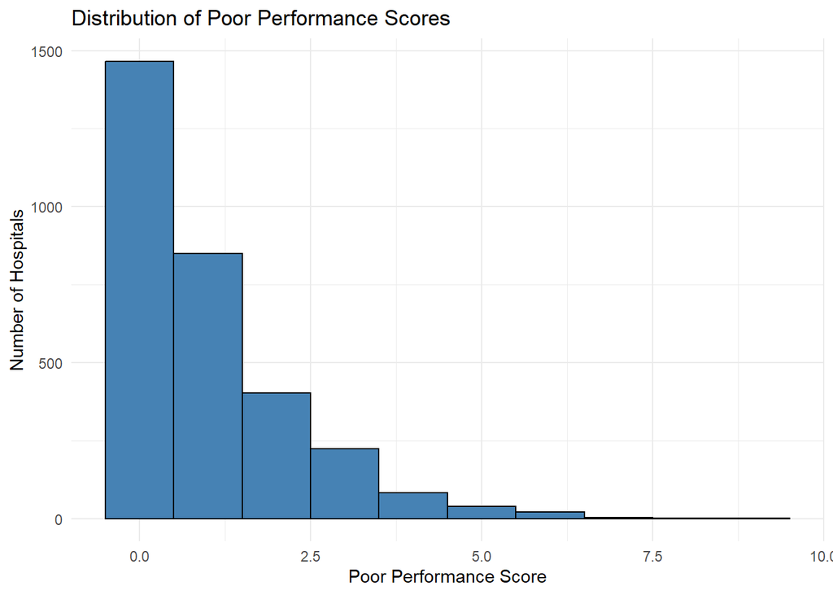

```r
ggplot(hospital_final,
       aes(x = PoorPerformanceScore)) +
  geom_histogram(binwidth = 1,
                 fill = "steelblue",
                 color = "black") +
  labs(
    title = "Distribution of Poor Performance Scores",
    x = "Poor Performance Score",
    y = "Number of Hospitals"
  ) +
  theme_minimal()
```

# 3 Exploratory Data Analysis

## 3.1 Distribution of the Poor Performance Score

```r
# Remove hospitals with missing Poor Performance Scores
hospital_analysis <- hospital_clean %>%
  filter(!is.na(PoorPerformanceScore))

# Summary statistics
summary(hospital_analysis$PoorPerformanceScore)
```

```
##    Min. 1st Qu.  Median    Mean 3rd Qu.    Max.
##  0.0000  0.0000  1.0000  0.9747  1.2500  9.0000
```

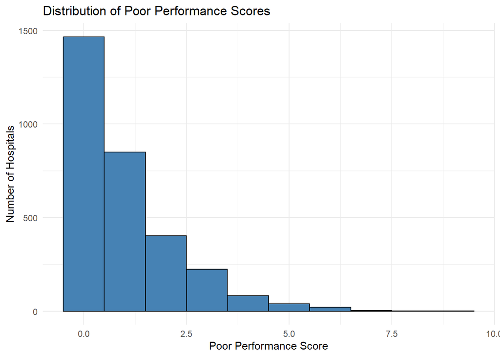

```r
# Histogram
ggplot(hospital_analysis,
       aes(x = PoorPerformanceScore)) +
  geom_histogram(
    binwidth = 1,
    fill = "steelblue",
    color = "black"
  ) +
  labs(
    title = "Distribution of Poor Performance Scores",
    x = "Poor Performance Score",
    y = "Number of Hospitals"
  ) +
  theme_minimal()
```

## 3.2 Hospital Ownership

```r
ownership_summary <- hospital_analysis %>%
  group_by(`Hospital Ownership`) %>%
  summarise(
    Hospitals = n(),
    MeanScore = mean(PoorPerformanceScore),
    MedianScore = median(PoorPerformanceScore),
    SD = sd(PoorPerformanceScore)
  ) %>%
  arrange(desc(MeanScore))

ownership_summary
```

```
## # A tibble: 11 × 5
##    `Hospital Ownership`                    Hospitals MeanScore MedianScore    SD
##    <chr>                                       <int>     <dbl>       <dbl> <dbl>
##  1 Government - State                             35     2.09          2    1.62
##  2 Veterans Health Administration                109     1.24          1    1.35
##  3 Government - Federal                           11     1.09          1    1.38
##  4 Physician                                      12     1.08          0.5  1.31
##  5 Proprietary                                   511     1.06          1    1.22
##  6 Voluntary non-profit - Private               1498     0.988         1    1.28
##  7 Voluntary non-profit - Church                 235     0.928         1    1.15
##  8 Government - Hospital District or Auth…       234     0.919         0    1.36
##  9 Voluntary non-profit - Other                  272     0.754         0    1.05
## 10 Government - Local                            168     0.685         0    1.05
## 11 Tribal                                          3     0.667         0    1.15
```

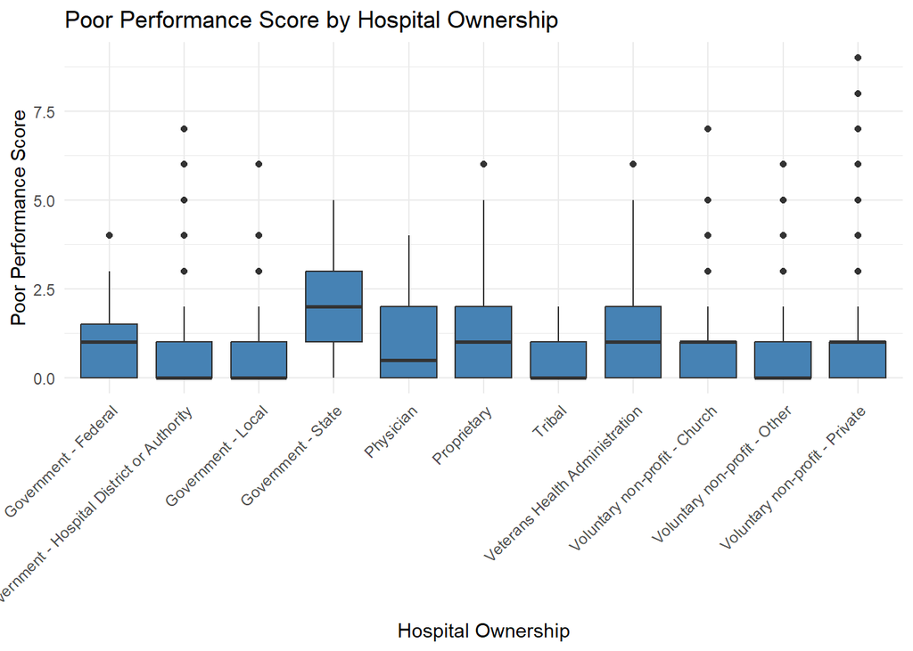

```r
ggplot(hospital_analysis,
       aes(x = `Hospital Ownership`,
           y = PoorPerformanceScore)) +
  geom_boxplot(fill = "steelblue") +
  labs(
    title = "Poor Performance Score by Hospital Ownership",
    x = "Hospital Ownership",
    y = "Poor Performance Score"
  ) +
  theme_minimal() +
  theme(
    axis.text.x = element_text(
      angle = 45,
      hjust = 1
    )
  )
```

Hospital Ownership. Government-owned state hospitals had the highest Poor Performance Scores. Most ownership groups had median scores of 0 or 1, although outliers were present across several ownership types.

## 3.3 Hospital Type

The Poor Performance Score was compared across hospital types to determine whether certain types of hospitals were associated with higher quality concerns.

```r
type_summary <- hospital_analysis %>%
  group_by(`Hospital Type`) %>%
  summarise(
    Hospitals = n(),
    MeanScore = round(mean(PoorPerformanceScore), 2),
    MedianScore = round(median(PoorPerformanceScore), 2),
    SD = round(sd(PoorPerformanceScore), 2)
  ) %>%
  arrange(desc(MeanScore))

type_summary
```

```
## # A tibble: 3 × 5
##   `Hospital Type`                      Hospitals MeanScore MedianScore    SD
##   <chr>                                    <int>     <dbl>       <dbl> <dbl>
## 1 Acute Care - Veterans Administration       109      1.24           1  1.35
## 2 Acute Care Hospitals                      2676      1.06           1  1.28
## 3 Critical Access Hospitals                  303      0.17           0  0.39
```

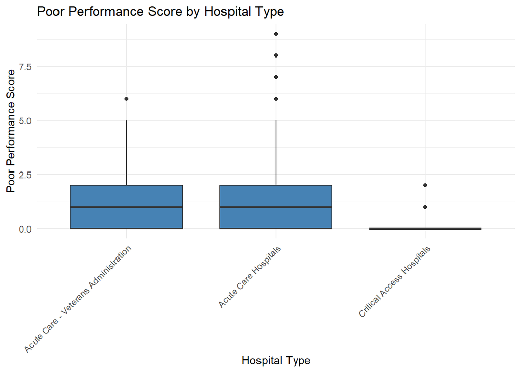

```r
ggplot(hospital_analysis,
       aes(x = `Hospital Type`,
           y = PoorPerformanceScore)) +
  geom_boxplot(fill = "steelblue") +
  labs(
    title = "Poor Performance Score by Hospital Type",
    x = "Hospital Type",
    y = "Poor Performance Score"
  ) +
  theme_minimal() +
  theme(
    axis.text.x = element_text(
      angle = 45,
      hjust = 1
    )
  )
```

*Hospital Type.* Hospital performance varied across hospital types. Differences in the median scores and several outliers suggest that hospital type may be associated with quality performance.

## 3.4 Emergency Services

The Poor Performance Score was compared between hospitals that provide emergency services and those that do not.

```r
emergency_summary <- hospital_analysis %>%
  group_by(`Emergency Services`) %>%
  summarise(
    Hospitals = n(),
    MeanScore = round(mean(PoorPerformanceScore), 2),
    MedianScore = round(median(PoorPerformanceScore), 2),
    SD = round(sd(PoorPerformanceScore), 2)
  )

emergency_summary
```

```
## # A tibble: 2 × 5
##   `Emergency Services` Hospitals MeanScore MedianScore    SD
##   <chr>                    <int>     <dbl>       <dbl> <dbl>
## 1 No                         128      0.66           0  0.85
## 2 Yes                       2960      0.99           1  1.27
```

Emergency Services. Hospitals with emergency services had higher Poor Performance Scores than hospitals without emergency services. The average score was 0.99 for hospitals with emergency services compared with 0.66 for hospitals without emergency services.

## 3.5 State Analysis

The average Poor Performance Score was calculated for each state.

```r
# Average Poor Performance Score by state
state_summary <- hospital_analysis %>%
  group_by(State) %>%
  summarise(
    Hospitals = n(),
    MeanScore = round(mean(PoorPerformanceScore), 2),
    .groups = "drop"
  ) %>%
  filter(Hospitals >= 20) %>%
  arrange(desc(MeanScore))

# Top 10 states with at least 20 hospitals
top10_states <- state_summary %>%
  slice_head(n = 10)

top10_states
```

```
## # A tibble: 10 × 3
##    State Hospitals MeanScore
##    <chr>     <int>     <dbl>
##  1 NJ           62      1.98
##  2 NY          136      1.74
##  3 MA           57      1.68
##  4 FL          166      1.58
##  5 NV           22      1.55
##  6 WV           34      1.47
##  7 MD           42      1.31
##  8 MS           50      1.26
##  9 AR           42      1.24
## 10 CT           26      1.23
```

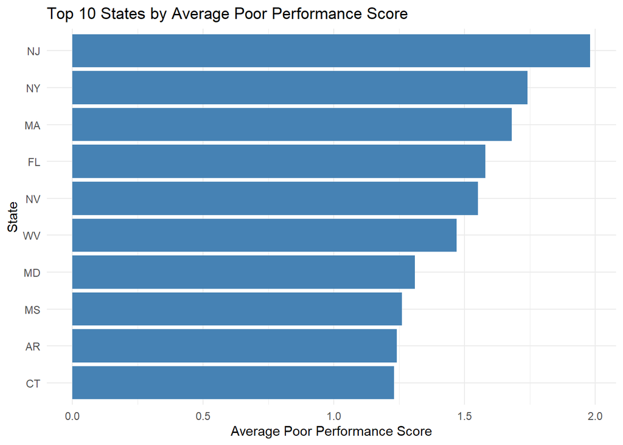

```r
ggplot(top10_states,
       aes(x = reorder(State, MeanScore),
           y = MeanScore)) +
  geom_col(fill = "steelblue") +
  coord_flip() +
  labs(
    title = "Top 10 States by Average Poor Performance Score",
    x = "State",
    y = "Average Poor Performance Score"
  ) +
  theme_minimal()
```

State Analysis. After limiting the analysis to states with at least 20 hospitals, New Jersey had the highest average Poor Performance Score, followed by New York and Massachusetts.

# 4 Correlation Analysis

The relationships between mortality, readmission, and safety measures were examined using Pearson correlation coefficients.

```r
# Select variables for correlation analysis
correlation_data <- hospital_analysis %>%
  select(
    mort_worse,
    readm_worse,
    safety_worse
  )

# Calculate correlation matrix
cor_matrix <- round(
  cor(
    correlation_data,
    use = "complete.obs"
  ),
  2
)

cor_matrix
```

```
##              mort_worse readm_worse safety_worse
## mort_worse         1.00        0.12         0.12
## readm_worse        0.12        1.00         0.19
## safety_worse       0.12        0.19         1.00
```

Correlation Analysis. The mortality, readmission, and safety measures showed weak positive correlations (0.12–0.19). This suggests that each measure provides different information about hospital performance and supports combining them into the Poor Performance Score.

# 5 Poor Performer Classification

Hospitals were classified as poor performers if their Poor Performance Score was at or above the 75th percentile. This binary outcome variable will be used in the Random Forest classification model.

```r
# Calculate the 75th percentile cutoff
cutoff <- quantile(
  hospital_analysis$PoorPerformanceScore,
  probs = 0.75,
  na.rm = TRUE
)

# Display the cutoff value
cutoff
```

```
##  75%
## 1.25
```

```r
# Create the Poor Performer classification
hospital_analysis <- hospital_analysis %>%
  mutate(
    PoorPerformer = ifelse(
      PoorPerformanceScore >= cutoff,
      "Yes",
      "No"
    )
  )

# Convert to a factor for modeling
hospital_analysis$PoorPerformer <- factor(
  hospital_analysis$PoorPerformer,
  levels = c("No", "Yes")
)

# Display the frequency of each class
table(hospital_analysis$PoorPerformer)
```

```
##
##   No  Yes
## 2316  772
```

**Poor Performer Classification.** Hospitals with Poor Performance Scores at or above the 75th percentile were classified as poor performers and used as the target variable for the Random Forest model.

Poor Performer Classification. Hospitals with a Poor Performance Score of 2 or greater (the top 25% of scores) were classified as poor performers. This resulted in 772 poor-performing hospitals and 2,316 non-poor-performing hospitals.

## 6.1 Prepare the Data

```r
# Select variables for the Random Forest model
rf_data <- hospital_analysis %>%
  select(
    PoorPerformer,
    `Hospital Ownership`,
    `Hospital Type`,
    `Emergency Services`,
    State,
    `Hospital overall rating`
  ) %>%
  drop_na() %>%
  filter(!State %in% c("GU", "VI"))

# Rename columns for modeling
colnames(rf_data) <- c(
  "PoorPerformer",
  "HospitalOwnership",
  "HospitalType",
  "EmergencyServices",
  "State",
  "HospitalRating"
)

str(rf_data)
```

```
## tibble [3,086 × 6] (S3: tbl_df/tbl/data.frame)
##  $ PoorPerformer    : Factor w/ 2 levels "No","Yes": 2 2 2 1 1 1 1 2 1 1 ...
##  $ HospitalOwnership: chr [1:3086] "Government - Hospital District or Authority" "Government - Hospital District or Authority" "Proprietary" "Voluntary non-profit - Private" ...
##  $ HospitalType     : chr [1:3086] "Acute Care Hospitals" "Acute Care Hospitals" "Acute Care Hospitals" "Acute Care Hospitals" ...
##  $ EmergencyServices: chr [1:3086] "Yes" "Yes" "Yes" "Yes" ...
##  $ State            : chr [1:3086] "AL" "AL" "AL" "AL" ...
##  $ HospitalRating   : chr [1:3086] "3" "2" "1" "1" ...
```

## 6.2 Split the Data

The dataset was randomly divided into training (80%) and testing (20%) sets. Predictor variables were converted to factors prior to fitting the Random Forest model.

```r
# Split the data
set.seed(50009)

train_index <- createDataPartition(
  rf_data$PoorPerformer,
  p = 0.80,
  list = FALSE
)

train_data <- rf_data[train_index, ]
test_data  <- rf_data[-train_index, ]

# Convert predictors to factors
factor_vars <- c(
  "HospitalOwnership",
  "HospitalType",
  "EmergencyServices",
  "State",
  "HospitalRating"
)

train_data[factor_vars] <- lapply(
  train_data[factor_vars],
  factor
)

test_data[factor_vars] <- lapply(
  test_data[factor_vars],
  factor
)

# Force identical factor levels
for(v in factor_vars){
  test_data[[v]] <- factor(
    test_data[[v]],
    levels = levels(train_data[[v]])
  )
}

# Convert to data frames
train_data <- as.data.frame(train_data)
test_data  <- as.data.frame(test_data)

# Display dimensions
dim(train_data)
```

```
## [1] 2469    6
```

```r
dim(test_data)
```

```
## [1] 617   6
```

## 6.3 Build the Random Forest Model

```r
set.seed(50009)

rf_model <- randomForest(
  PoorPerformer ~ .,
  data = train_data,
  ntree = 500,
  importance = TRUE
)

rf_model
```

```
##
## Call:
##  randomForest(formula = PoorPerformer ~ ., data = train_data,      ntree = 500, importance = TRUE)
##                Type of random forest: classification
##                      Number of trees: 500
## No. of variables tried at each split: 2
##
##         OOB estimate of  error rate: 22.64%
## Confusion matrix:
##       No Yes class.error
## No  1678 174  0.09395248
## Yes  385 232  0.62398703
```

## 6.4 Evaluate Model Performance

The Random Forest model was evaluated using the independent testing dataset. Model performance was summarized using a confusion matrix.

```r
# Predict Poor Performer status for the testing data
rf_predictions <- predict(
  rf_model,
  newdata = test_data
)

# Create the confusion matrix
rf_results <- confusionMatrix(
  rf_predictions,
  test_data$PoorPerformer
)

# Display the results
rf_results
```

```
## Confusion Matrix and Statistics
##
##           Reference
## Prediction  No Yes
##        No  410  87
##        Yes  53  67
##
##                Accuracy : 0.7731
##                  95% CI : (0.738, 0.8056)
##     No Information Rate : 0.7504
##     P-Value [Acc > NIR] : 0.103722
##
##                   Kappa : 0.3461
##
##  Mcnemar's Test P-Value : 0.005287
##
##             Sensitivity : 0.8855
##             Specificity : 0.4351
##          Pos Pred Value : 0.8249
##          Neg Pred Value : 0.5583
##              Prevalence : 0.7504
##          Detection Rate : 0.6645
##    Detection Prevalence : 0.8055
##       Balanced Accuracy : 0.6603
##
##        'Positive' Class : No
##
```

## 6.5 Variable Importance

The Random Forest model calculates the relative importance of each predictor variable. Variables with higher importance contribute more to correctly classifying hospitals as poor performers.

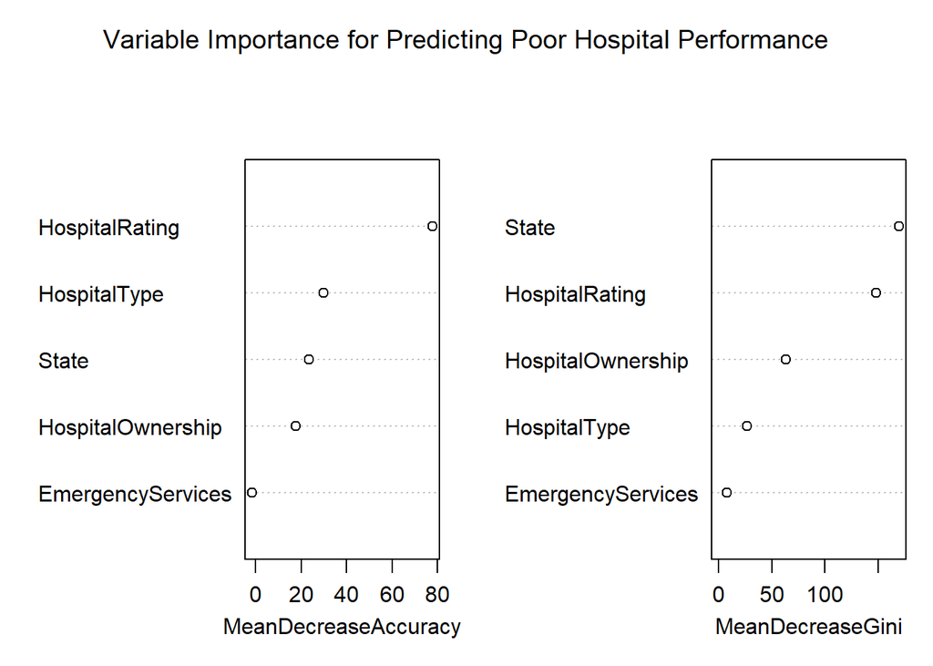

```r
# Display the variable importance plot
varImpPlot(
  rf_model,
  main = "Variable Importance for Predicting Poor Hospital Performance"
)
```

**Variable Importance.** The variable importance plot ranks the predictor variables based on their contribution to the Random Forest model. Variables with higher importance scores have a greater influence on predicting whether a hospital is classified as a poor performer.

# 7 Executive Summary

This project examined characteristics associated with poor hospital performance using publicly available CMS hospital quality data. A Poor Performance Score was developed by combining mortality, readmission, and patient safety measures in which hospitals performed worse than the national average.

Exploratory analyses found differences in Poor Performance Scores across hospital ownership, hospital type, emergency service availability, and geographic location. Government-owned state hospitals generally had the highest average Poor Performance Scores, while Critical Access Hospitals tended to have the lowest scores.